# Reproducible Research: Peer Assessment 2

## 1. Title: Research Study on Impact of Storms and Severe Weather Events on Public Health and Economy

## 2. Synopsis

## In this research study, we have analyzed the impact of storms and other severe weather events on public health and the economy using data from the U.S. National Oceanic and Atmospheric Administration’s (NOAA) storm database with events collected from 1950 - 2011. There are two research questions addressed by this study: 1. Across the United States, which types of events (as indicated in the EVTYPE variable) are most harmful with respect to the population health (i.e., highest mortality rates); 2. Across the United States, which types of events have caused the greatest economic consequences (i.e., highest estimated property damage). The top 3 severe weather events in the U.S. from 1991 - 2011 causing injuries are Tornado, Heavy Wind Storm, and Flood. The top 3 severe weather events in the U.S. from 1991 - 2011 causing fatalities are Heavy Wind Storm, Excessive Heat, and Tornado. The top 3 severe weather events in the U.S. from 1991 - 2011 causing crop damage as a measure of economic consequence are Hot Weather, Heavy Wind Storm, and Flood. The top 3 severe weather events in the U.S. from 1991 - 2011 causing property damage are Heavy Wind Storm, Flood, and Tornado.

## 3. Data Processing

## This section provides details on the data processing performed on the NOAA dataset.

### 3.1 Basic Global Settings

```r
echo = TRUE          # Always make code visible
options(scipen = 1)  # Turn off scientific notations for numbers
```

### 3.2 Plotting System and Other Libraries

```r
library(ggplot2)    # for plots
library(R.utils)    # for bunzip2
library(lubridate)  # for date/time conversions
library(grid)       # for grid graphics package
library(plyr)       # for split-apply paradigm
library(gridExtra)  # for extra functions of grid such as arrange
```

### 3.3 Keeping track of my software environment

```r
setwd("~/Documents/RepData_PeerAssessment2/")
```

### 3.4 Perform download of file using reproducible research best practice of no manual intervention and computer performing all tasks

```r
if(!file.exists("~/Downloads/StormData.csv.bz2")){
  download.file(url="https://d396qusza40orc.cloudfront.net/repdata%2Fdata%2FStormData.csv.bz2",
                destfile="~/Downloads/StormData.csv.bz2")
}
```

### 3.5 Loading and preprocessing the data as this is a very large dataset, only read it in if it does not exist in environment.

```r
if(!file.exists("~/Downloads/StormData.csv")){
    bunzip2(filename="~/Downloads/StormData.csv.bz2", destname="~/Downloads/StormData.csv", overwrite=TRUE, remove=FALSE)
}
if (!"stormData" %in% ls()){
    stormData <- read.csv("~/Downloads/StormData.csv")
}
```

- There are 902297 rows and 37 columns in the dataset.

### 3.6. Process/transform the data (if necessary) into a format suitable for the analysis.

#### 3.6.1 Let’s remove irrelevant columns and rows. Events in the dataset were collected from 1950 to 2011.

#### We know more data was collected in the later years looking at the histogram so lets look at

#### the last 20 years of the data, 1991 to 2011.

```r
dim(stormData)
```

```
## [1] 902297     37
```

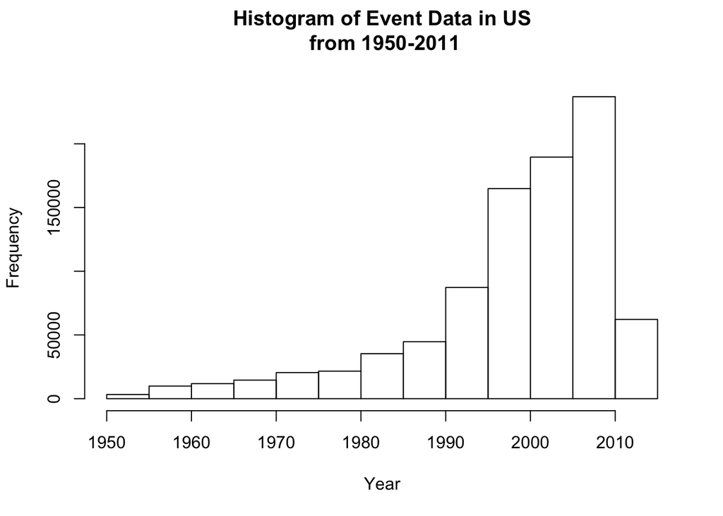

```r
smallData <- stormData[, c("BGN_DATE", "EVTYPE", "FATALITIES", "INJURIES", "PROPDMG", "PROPDMGEXP", "CROPDMG", "CROPDMGEXP")]
smallData$YEAR <- as.numeric(year(mdy_hms(smallData[,1])))
hist(smallData$YEAR, main="Histogram of Event Data in US\n from 1950-2011\n", xlab="Year", ylab="Frequency")
```

```r
smallData <- smallData[smallData$YEAR >= 1991, ]
#
# Let's explore the data first to understand transformations to be made
unique(smallData$YEAR)
```

```
##  [1] 1991 1992 1995 1994 1993 1996 1997 1998 1999 2000 2001 2002 2003 2004
## [15] 2005 2006 2007 2008 2009 2010 2011
```

```r
unique(smallData$EVTYPE)
```

```
##   [1] TSTM WIND                      HAIL
##   [3] TORNADO                        FREEZING RAIN
##   [5] SNOW                           ICE STORM/FLASH FLOOD
##   [7] SNOW/ICE                       WINTER STORM
##   [9] HURRICANE OPAL/HIGH WINDS      THUNDERSTORM WINDS
##  [11] RECORD COLD                    HURRICANE ERIN
##  [13] HURRICANE OPAL                 HEAVY RAIN
##  [15] LIGHTNING                      THUNDERSTORM WIND
##  [17] DENSE FOG                      RIP CURRENT
##  [19] THUNDERSTORM WINS              FLASH FLOOD
##  [21] FLASH FLOODING                 HIGH WINDS
##  [23] FUNNEL CLOUD                   TORNADO F0
##  [25] THUNDERSTORM WINDS LIGHTNING   THUNDERSTORM WINDS/HAIL
##  [27] HEAT                           WIND
##  [29] LIGHTING                       HEAVY RAINS
```

[output cut: 479 more lines]

```r
unique(smallData$PROPDMGEXP)
```

```
##  [1]   K M B m + 0 5 6 ? 4 2 3 h 7 H - 1 8
## Levels:  - ? + 0 1 2 3 4 5 6 7 8 B h H K m M
```

```r
unique(smallData$CROPDMGEXP)
```

```
## [1]   M K m B ? 0 k 2
## Levels:  ? 0 2 B k K m M
```

#### 3.6.2.1 Transformation 1:Set property and crop damage variables to a numeric value based on exponent. Replace invalid expressions with a numeric value of 0.Both PROPDMGEXP and CROPDMGEXP columns contain a multiplier for each observation for example where we have Hundred (H), Thousand (K), Million (M) and Billion (B).

```r
# Transformation function
transform <- function (fData = smallData, f1, fexp) {
fData[(fData[,fexp] == "+"), f1] <- 0
fData[(fData[,fexp] == "-"), f1] <- 0
fData[(fData[,fexp] == "?"), f1] <- 0

fData[(fData[,fexp] ==  ""),  f1] <- fData[(fData[,fexp] ==  ""),  f1]  * 1e+00
fData[(fData[,fexp] == "0"),  f1] <- fData[(fData[,fexp] == "0"),  f1]  * 1e+00
fData[(fData[,fexp] == "1"),  f1] <- fData[(fData[,fexp] == "1"),  f1]  * 1e+01
fData[(fData[,fexp] == "2"),  f1] <- fData[(fData[,fexp] == "2"),  f1]  * 1e+02
fData[(fData[,fexp] == "3"),  f1] <- fData[(fData[,fexp] == "3"),  f1]  * 1e+03
fData[(fData[,fexp] == "4"),  f1] <- fData[(fData[,fexp] == "4"),  f1]  * 1e+04
fData[(fData[,fexp] == "5"),  f1] <- fData[(fData[,fexp] == "5"),  f1]  * 1e+05
fData[(fData[,fexp] == "6"),  f1] <- fData[(fData[,fexp] == "6"),  f1]  * 1e+06
fData[(fData[,fexp] == "7"),  f1] <- fData[(fData[,fexp] == "7"),  f1]  * 1e+07
fData[(fData[,fexp] == "8"),  f1] <- fData[(fData[,fexp] == "8"),  f1]  * 1e+08
fData[(fData[,fexp] == "9"),  f1] <- fData[(fData[,fexp] == "9"),  f1]  * 1e+09

fData[(toupper(fData[,fexp]) == "H"),  f1] <- fData[(toupper(fData[,fexp]) == "H"),  f1]  * 1e+02
fData[(toupper(fData[,fexp]) == "K"),  f1] <- fData[(toupper(fData[,fexp]) == "K"),  f1]  * 1e+03
fData[(toupper(fData[,fexp]) == "M"),  f1] <- fData[(toupper(fData[,fexp]) == "M"),  f1]  * 1e+06
fData[(toupper(fData[,fexp]) == "B"),  f1] <- fData[(toupper(fData[,fexp]) == "B"),  f1]  * 1e+09
return (fData)
}
dataSet <-transform(smallData, which(colnames(smallData) == "PROPDMG"), which(colnames(smallData) == "PROPDMGEXP"))
dataSet <-transform(smallData, which(colnames(smallData) == "CROPDMG"), which(colnames(smallData) == "CROPDMGEXP"))
```

#### 3.6.2.1 Transformation 2: Group together Event Types (EVTYPE) using grep and ignoring case statements as there are too many different event types.

```r
# EVTYPE Transformation function
dataSet$EVTYPE <- as.character(dataSet$EVTYPE)
dataSet$EVTYPE[grepl("tsunami|astronomical|rogue|hazardous|marine|current|tide",
                     dataSet$EVTYPE,ignore.case = TRUE)] <- "TSUNAMI/HIGH CURRENT"
dataSet$EVTYPE[grepl("thunderstorm|lightning|gusty thunderstorm",
                     dataSet$EVTYPE,ignore.case = TRUE)] <- "THUNDERSTORM/LIGHTNING"
dataSet$EVTYPE[grepl("flood",
                     dataSet$EVTYPE,ignore.case = TRUE)] <- "FLOOD"
dataSet$EVTYPE[grepl("slide|erosion",
                     dataSet$EVTYPE,ignore.case = TRUE)] <- "LANDSLIDE/EROSION"
dataSet$EVTYPE[grepl("heavy rain | hail|precipitation|burst",
                     dataSet$EVTYPE,ignore.case = TRUE)] <- "HEAVYRAIN/HAILSTORM"
dataSet$EVTYPE[grepl("freeze|cold|winter weather mix|snow|chill|patchy ice",
                     dataSet$EVTYPE,ignore.case = TRUE)] <- "COLD WEATHER"
dataSet$EVTYPE[grepl("wind |storm|hurricane|typhoon|tstm wind|high wind",
                     dataSet$EVTYPE,ignore.case = TRUE)] <- "HEAVY WIND STORM"
dataSet$EVTYPE[grepl("fire|smoke|dense smoke",
                     dataSet$EVTYPE,ignore.case = TRUE)] <- "FIRE/SMOKE"
dataSet$EVTYPE[grepl("hot|drought|temperature record|record temperature|record high|dry",
                     dataSet$EVTYPE,ignore.case = TRUE)] <- "HOT WEATHER"
dataSet$EVTYPE[grepl("tornado", dataSet$EVTYPE,ignore.case = TRUE)] <- "TORNADO"
```

- After processing, there are 740794 rows and 9 columns in the dataset.

## 4. Results

```r
sumFatalities  <- head(arrange(aggregate(FATALITIES ~ EVTYPE, dataSet, sum), desc(FATALITIES)),n=10)
sumInjuries    <- head(arrange(aggregate(INJURIES ~ EVTYPE,   dataSet, sum), desc(INJURIES)),  n=10)
sumPropDamage  <- head(arrange(aggregate(PROPDMG ~ EVTYPE, dataSet, sum),    desc(PROPDMG)),   n=10)
sumCropDamage  <- head(arrange(aggregate(CROPDMG ~ EVTYPE, dataSet, sum),    desc(CROPDMG)),   n=10)

head(sumFatalities)
```

```
##                 EVTYPE FATALITIES
## 1     HEAVY WIND STORM       2173
## 2       EXCESSIVE HEAT       1903
## 3              TORNADO       1702
## 4                FLOOD       1525
## 5                 HEAT        937
## 6 TSUNAMI/HIGH CURRENT        663
```

```r
head(sumInjuries)
```

```
##             EVTYPE INJURIES
## 1          TORNADO    25558
## 2 HEAVY WIND STORM    19270
## 3            FLOOD     8604
## 4   EXCESSIVE HEAT     6525
## 5             HEAT     2100
## 6       FIRE/SMOKE     1608
```

```r
head(sumPropDamage)
```

```
##             EVTYPE   PROPDMG
## 1 HEAVY WIND STORM 3963933.7
## 2            FLOOD 2435606.5
## 3          TORNADO 1522662.1
## 4             HAIL  688693.4
## 5     COLD WEATHER  169164.7
## 6       FIRE/SMOKE  125318.3
```

```r
head(sumCropDamage)
```

```
##             EVTYPE     CROPDMG
## 1      HOT WEATHER 13972621780
## 2 HEAVY WIND STORM 13255597278
## 3            FLOOD 12380079100
## 4     COLD WEATHER  3457489650
## 5             HAIL  3025954473
## 6       HEAVY RAIN   733399800
```

### 4.2 Results of the data analysis to addresses the following questions:

#### 4.2.1 Across the United States, which types of events (as indicated in the EVTYPE variable) are most harmful with respect to population health? The results in terms of injuries and fatalities are:

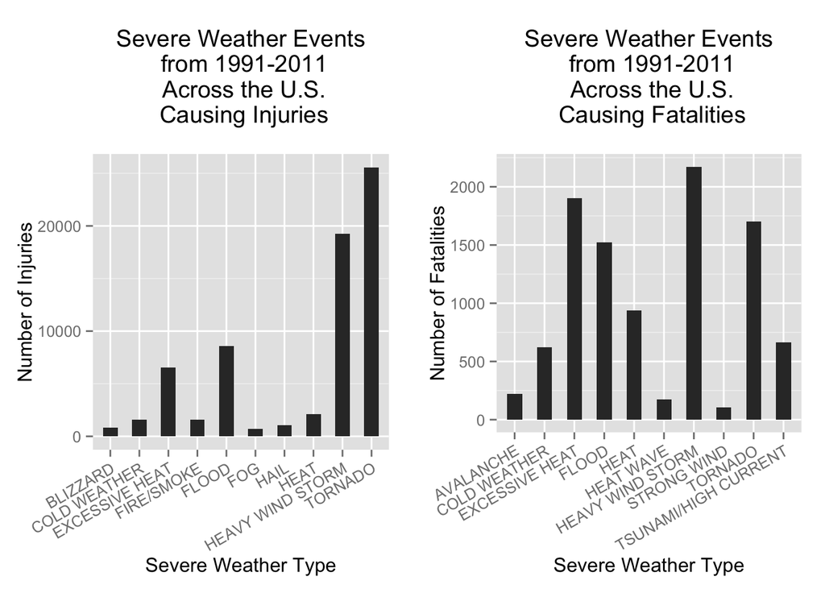

```r
gg1 <- ggplot(sumInjuries, aes(EVTYPE, INJURIES)) +
  geom_bar(stat = "identity", width = 0.5) +
  scale_y_continuous("Number of Injuries") +
  theme(axis.text.x = element_text(angle = 30, hjust = 1)) +
  labs(title = "Severe Weather Events\n from 1991-2011\n Across the U.S.\n Causing Injuries\n ", x = "Severe Weather Type")

gg2 <- ggplot(sumFatalities, aes(EVTYPE, FATALITIES)) +
  geom_bar(stat = "identity", width = 0.5) +
  scale_y_continuous("Number of Fatalities") +
  theme(axis.text.x = element_text(angle = 30, hjust = 1)) +
  labs(title = "Severe Weather Events\n from 1991-2011\n Across the U.S.\n Causing Fatalities\n ", x = "Severe Weather Type")

grid.arrange (gg1, gg2, ncol=2, padding=3)
```

#### The top 3 severe weather events in the U.S. from 1991 - 2011 causing injuries are Tornado, Heavy Wind Storm, and Flood. The top 3 severe weather events in the U.S. from 1991 - 2011 causing fatalities are Heavy Wind Storm, Excessive Heat, and Tornado.

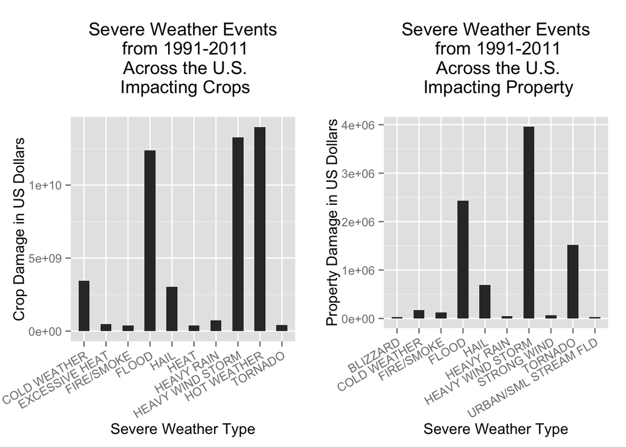

```r
gg1 <- ggplot(sumCropDamage, aes(EVTYPE, CROPDMG)) +
  geom_bar(stat = "identity", width = 0.5) +
  scale_y_continuous("Crop Damage in US Dollars") +
  theme(axis.text.x = element_text(angle = 30, hjust = 1)) +
  labs(title = "Severe Weather Events\n from 1991-2011\n Across the U.S.\n Impacting Crops\n ", x = "Severe Weather Type")

gg2 <- ggplot(sumPropDamage, aes(EVTYPE, PROPDMG)) +
  geom_bar(stat = "identity", width = 0.5) +
  scale_y_continuous("Property Damage in US Dollars") +
  theme(axis.text.x = element_text(angle = 30, hjust = 1)) +
  labs(title = "Severe Weather Events\n from 1991-2011\n Across the U.S.\n Impacting Property\n ", x = "Severe Weather Type")

grid.arrange (gg1, gg2, ncol=2, padding=3)
```

#### The top 3 severe weather events in the U.S. from 1991 - 2011 causing crop damage as a measure of economic consequence are Hot Weather, Heavy Wind Storm, and Flood. The top 3 severe weather events in the U.S. from 1991 - 2011 causing property damage are Heavy Wind Storm, Flood, and Tornado.